# Evaluation-of-filter-results_100x25

Kento Okuyama

2023-11-09

## (very) Brief introduction

In this document, we evaluate the implementation of our frequentist implementation of the non-linear regime-switching state-space (RSSS) model estimation based on simulated data. Our parameter optimization consists of 300 iteration steps based on Adam. On top of that, we have 30 initialization of the starting parameter values.

In our implementation, our objective function **sumLik** is maximized based on the gradient vector and Adam. For evaluation purpose, we also have the score function **delta**. This is simply calculated as the summed squared error of the one-step-ahead (of the last observed time points) prediction of our intra-individual latent variables. Further, we also have **sensitivity** and **specificity** based on the one-step-ahead regime prediction results.

```r
print(filter1$output_best)
```

```
##   init iter   sumLik TP TN FP FN sensitivity specificity    delta
## 1   30  247 442153.2  0 96  0  4           0           1 40.39857
```

```r
summary(filter1$output_list)
```

```
##       init            iter            sumLik                TP
##  Min.   : 1.00   Min.   :  1.00   Min.   :0.000e+00   Min.   :0.0000
##  1st Qu.: 8.00   1st Qu.: 41.00   1st Qu.:4.100e+01   1st Qu.:0.0000
##  Median :16.00   Median : 82.00   Median :9.500e+01   Median :0.0000
##  Mean   :15.95   Mean   : 98.74   Mean   :1.472e+10   Mean   :0.5902
##  3rd Qu.:24.00   3rd Qu.:151.00   3rd Qu.:8.820e+02   3rd Qu.:0.0000
##  Max.   :30.00   Max.   :300.00   Max.   :2.386e+13   Max.   :4.0000
##        TN              FP                FN        sensitivity
##  Min.   : 0.00   Min.   : 0.0000   Min.   :0.00   Min.   :0.0000
##  1st Qu.:96.00   1st Qu.: 0.0000   1st Qu.:4.00   1st Qu.:0.0000
##  Median :96.00   Median : 0.0000   Median :4.00   Median :0.0000
##  Mean   :95.76   Mean   : 0.2417   Mean   :3.41   Mean   :0.1475
##  3rd Qu.:96.00   3rd Qu.: 0.0000   3rd Qu.:4.00   3rd Qu.:0.0000
##  Max.   :96.00   Max.   :96.0000   Max.   :4.00   Max.   :1.0000
##   specificity         delta
##  Min.   :0.0000   Min.   :1.300e+01
##  1st Qu.:1.0000   1st Qu.:1.700e+01
##  Median :1.0000   Median :2.000e+01
##  Mean   :0.9975   Mean   :1.470e+13
##  3rd Qu.:1.0000   3rd Qu.:2.600e+01
##  Max.   :1.0000   Max.   :3.581e+16
```

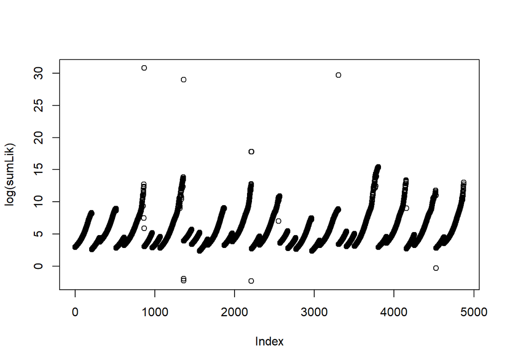

```r
plot(log(filter1$output_list$sumLik), ylab='log(sumLik)')
```

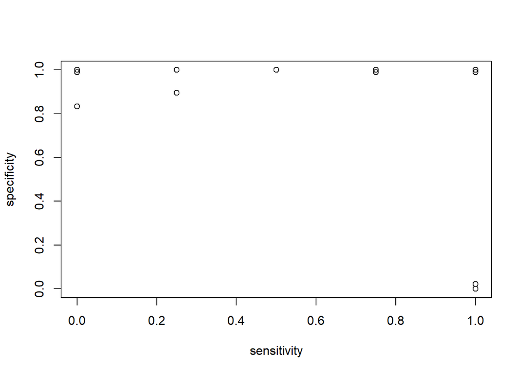

```r
plot(filter1$output_list$sensitivity, filter1$output_list$specificity, xlab='sensitivity', ylab='specificity')
```

```r
cor(filter1$output_list$sensitivity, filter1$output_list$specificity)
```

```
## [1] -0.1288679
```

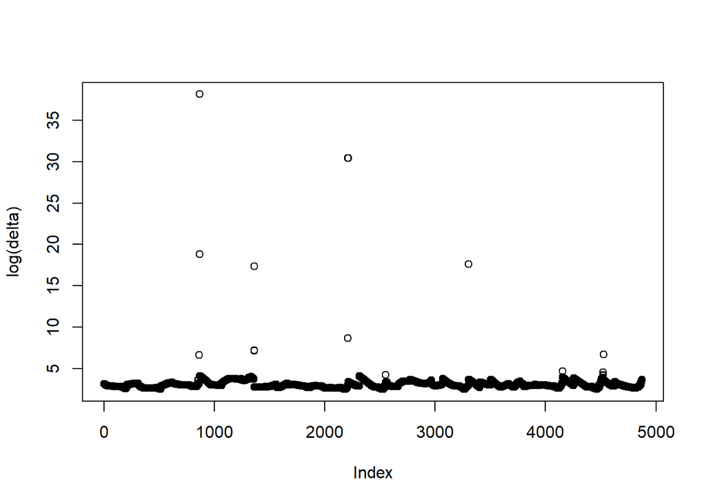

```r
plot(log(filter1$output_list$delta), ylab='log(delta)')
```

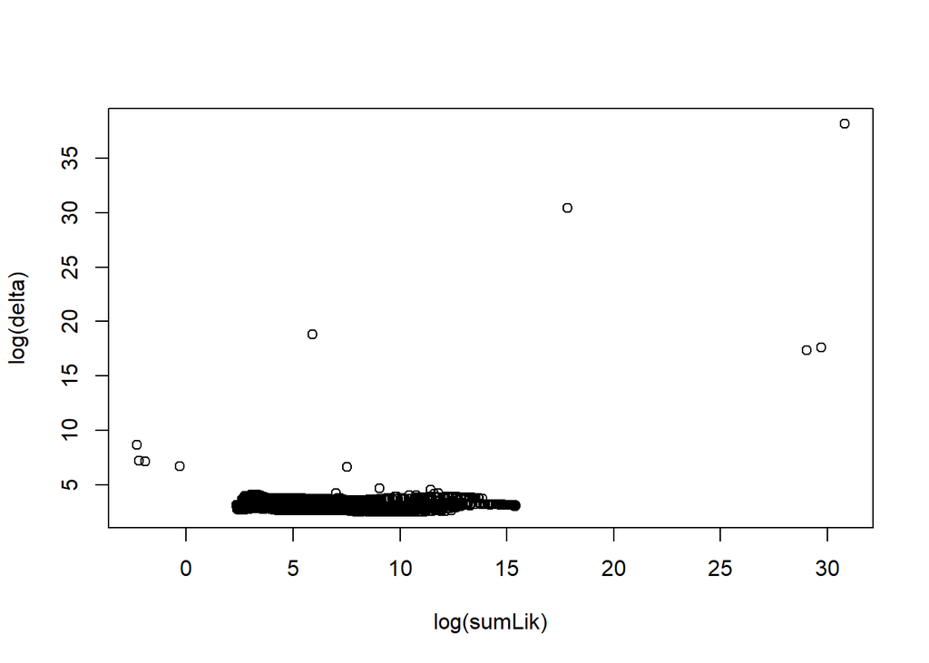

```r
plot(log(filter1$output_list$sumLik), log(filter1$output_list$delta), xlab='log(sumLik)', ylab='log(delta)')
```

```r
cor(log(filter1$output_list$sumLik), log(filter1$output_list$delta))
```

```
## [1] 0.2105031
```